# Learning x Motivation Main Analysis and Figures

Calum Guinea

2026-08-03

# Overview

This notebook provides a complete workflow for analyzing Learning x Motivation (LxM) data including:

- Data loading and preprocessing
- Mixed model fitting and comparison
- Publication-quality visualizations (exact replications of original code)
- Statistical analyses

**To use this notebook:** keep this file and the `data/` folder together, then click “Knit”. No paths to edit.

```
your-folder/
├── LxM_analysis_mainFigs.Rmd
└── data/
    ├── choice_trialByTrial.csv
    ├── summaryFull.csv
    └── allEstsByStim.csv
```

# Setup

## Locate the Data Folder

```r
# Folder holding the raw CSVs, next to this .Rmd file
data_dir <- file.path("data")
required_files <- c("choice_trialByTrial.csv", "summaryFull.csv", "allEstsByStim.csv")

# Fail early with a clear message if a file is missing, rather than a
# cryptic error later in the notebook
missing_files <- required_files[!file.exists(file.path(data_dir, required_files))]
if (length(missing_files) > 0) {
  stop("Missing data file(s): ", paste(missing_files, collapse = ", "),
       "\nExpected them in: ", normalizePath(data_dir, mustWork = FALSE))
}
```

## Install Packages (if needed)

Run this chunk once if you need to install packages:

```r
install.packages(c("dplyr", "tidyr", "lme4", "ggplot2", "ggeffects",
                   "broom.mixed", "ggdist", "ggpubr", "ppcor", "corrplot",
                   "reshape2", "knitr", "DT", "gridExtra"))
```

## Load Packages

```r
library(dplyr)
library(tidyr)
library(lme4)
library(ggplot2)
library(ggeffects)
library(broom.mixed)
library(ggdist)
library(ggpubr)
library(ppcor)
library(corrplot)
library(reshape2)
# library(knitr)
library(DT)
library(gridExtra)
```

# Data Loading and Preprocessing

## Define Preprocessing Function

This function loads the data files and prepares them for analysis by:

- Converting valence to binary (0 = loss, 1 = reward)
- Scaling continuous predictors (mean-centering and standardizing)
- Optionally excluding participants with poor tournament performance

```r
load_and_preprocess_data <- function(exclude_low_performance = TRUE) {

  # Read data files from the data/ subfolder (built above as `data_dir`)
  tbtDf <- read.csv(file.path(data_dir, "choice_trialByTrial.csv"))
  summDf <- read.csv(file.path(data_dir, "summaryFull.csv"))

  # Rename ID column for consistency
  summDf <- summDf %>% rename(prolificID = ParticipantId)

  # Convert valence to binary factor (0 = loss, 1 = reward)
  tbtDf <- tbtDf %>% mutate(valence = ifelse(valence == -1, 0, 1))
  tbtDf$valence <- as.factor(tbtDf$valence)

  # Scale continuous predictors (mean-centered and standardized)
  # Learning fidelity measures
  tbtDf$postLearnRat_resc <- scale(tbtDf$postLearnRat)
  tbtDf$postTournRat_resc <- scale(tbtDf$postTournRat)
  tbtDf$postEffortRat_resc <- scale(tbtDf$postEffortRat)
  tbtDf$meanEstByStim_resc <- scale(tbtDf$meanEstByStim)
  tbtDf$finLearningEst_resc <- scale(tbtDf$finLearningEst)

  # Decision variables
  tbtDf$effDiscEV <- scale(tbtDf$effDiscEV)
  tbtDf$alienEV <- scale(tbtDf$alienEV)

  # Demographics
  tbtDf$Age_resc <- scale(tbtDf$Age)
  tbtDf$Sex <- as.factor(tbtDf$Sex)
  tbtDf$Gender <- as.factor(tbtDf$Gender)

  # Questionnaire scores
  tbtDf$SHAPS_resc <- scale(tbtDf$SHAPS)
  summDf$SHAPS_resc <- scale(summDf$SHAPS)
  tbtDf$AD_resc <- scale(tbtDf$AD)
  tbtDf$SW_resc <- scale(tbtDf$SW)
  tbtDf$Compul_resc <- scale(tbtDf$Compul)
  tbtDf$FAS_resc <- scale(tbtDf$FAS)
  tbtDf$AES_resc <- scale(tbtDf$AES)
  tbtDf$STAI_resc <- scale(tbtDf$STAI)

  summDf$FAS_resc <- scale(summDf$FAS)
  summDf$AES_resc <- scale(summDf$AES)
  summDf$STAI_resc <- scale(summDf$STAI)

  # Exclude participants with poor tournament performance if requested
  if (exclude_low_performance) {
    threshold <- 50  # Above chance performance
    tbtDf <- tbtDf[tbtDf$ovrperc > threshold, ]
    summDf <- summDf[summDf$ovrperc > threshold, ]
  }

  # Create expected value difference variable
  tbtDf <- tbtDf %>%
    mutate(evDiff = ifelse(
      outMag < 0,
      (abs(outMag) * outProb) - (abs(outMag) * 1),
      (abs(outMag) * outProb) - (abs(outMag) * 0)
    ))
  tbtDf$evDiff <- abs(tbtDf$evDiff)

  return(list(tbtDf = tbtDf, summDf = summDf))
}
```

## Load Data

```r
data <- load_and_preprocess_data(exclude_low_performance = TRUE)
tbtDf <- data$tbtDf
summDf <- data$summDf
```

## Sample Characteristics

```r
cat(sprintf("Sample size: %d participants\n", length(unique(tbtDf$prolificID))))
```

```
## Sample size: 252 participants
```

```r
cat(sprintf("Total trials: %d\n", nrow(tbtDf)))
```

```
## Total trials: 24192
```

```r
cat(sprintf("Mean age: %.1f (SD = %.1f)\n",
            mean(summDf$Age, na.rm = TRUE), sd(summDf$Age, na.rm = TRUE)))
```

```
## Mean age: 38.9 (SD = 11.9)
```

## Baseline Model Comparison

This section fits a baseline GLM without random effects to test whether the fixed effects significantly improve model fit compared to a null (intercept-only) model.

```r
# Fit baseline model with all fixed effects (no random effects)
# This model includes demographics and all decision variables
baseGlm <- glm(accepted ~ Age_resc + Gender + SES + ord + outProb + normOutMag + effPrp + valence,
               data = tbtDf,
               family = "binomial")

# Display model summary
summary(baseGlm)
```

```
##
## Call:
## glm(formula = accepted ~ Age_resc + Gender + SES + ord + outProb +
##     normOutMag + effPrp + valence, family = "binomial", data = tbtDf)
##
## Coefficients:
##                                                    Estimate Std. Error z value
## (Intercept)                                        4.973354   0.141606  35.121
## Age_resc                                           0.040035   0.016885   2.371
## GenderNon-binary (would like to give more detail) -1.060905   0.232695  -4.559
## GenderRather not say                               0.765016   0.303813   2.518
## GenderWoman (including Trans Female/Trans Woman)   0.265248   0.033420   7.937
## SES                                               -0.008681   0.010027  -0.866
## ord                                               -0.102366   0.033295  -3.074
## outProb                                            2.579672   0.069652  37.037
## normOutMag                                         0.773704   0.055577  13.921
## effPrp                                            -7.004996   0.149152 -46.966
## valence1                                           0.223706   0.033175   6.743
##                                                   Pr(>|z|)
## (Intercept)                                        < 2e-16 ***
## Age_resc                                           0.01774 *
## GenderNon-binary (would like to give more detail) 5.13e-06 ***
## GenderRather not say                               0.01180 *
## GenderWoman (including Trans Female/Trans Woman)  2.08e-15 ***
## SES                                                0.38663
## ord                                                0.00211 **
## outProb                                            < 2e-16 ***
## normOutMag                                         < 2e-16 ***
## effPrp                                             < 2e-16 ***
## valence1                                          1.55e-11 ***
## ---
## Signif. codes:  0 '***' 0.001 '**' 0.01 '*' 0.05 '.' 0.1 ' ' 1
##
## (Dispersion parameter for binomial family taken to be 1)
##
##     Null deviance: 26668  on 24191  degrees of freedom
## Residual deviance: 22446  on 24181  degrees of freedom
## AIC: 22468
##
## Number of Fisher Scoring iterations: 5
```

```r
# Fit null model (intercept only)
# This serves as a baseline for comparison
nullGlm <- glm(accepted ~ 1,
               data = tbtDf,
               family = "binomial")

# Display null model summary
summary(nullGlm)
```

```
##
## Call:
## glm(formula = accepted ~ 1, family = "binomial", data = tbtDf)
##
## Coefficients:
##             Estimate Std. Error z value Pr(>|z|)
## (Intercept)  1.15224    0.01505   76.55   <2e-16 ***
## ---
## Signif. codes:  0 '***' 0.001 '**' 0.01 '*' 0.05 '.' 0.1 ' ' 1
##
## (Dispersion parameter for binomial family taken to be 1)
##
##     Null deviance: 26668  on 24191  degrees of freedom
## Residual deviance: 26668  on 24191  degrees of freedom
## AIC: 26670
##
## Number of Fisher Scoring iterations: 4
```

```r
# Compare baseline model to null model using likelihood ratio test
# Tests whether adding predictors significantly improves model fit
anova(baseGlm, nullGlm, test = "Chi")
```

|  | Resid. Df | Resid. Dev | Df | Deviance | Pr(>Chi) |
| --- | --- | --- | --- | --- | --- |
| 1 | 24181 | 22446.09 | NA | NA | NA |
| 2 | 24191 | 26667.88 | -10 | -4221.782 | 0 |

# Model Fitting

## Define Model Formulas

We compare two sets of models:

1. **Learning measure models**: Compare different ways of measuring individualized learning
2. **Mental health models**: Test effects of psychiatric symptoms on effort-based decisions

```r
# Set 1: Compare different individualized learning measures
learning_models <- list(
  base = accepted ~ Age_resc + Gender + outProb + normOutMag + effPrp + valence +
    (1 + outProb + normOutMag + effPrp + valence | prolificID),

  post_learn = accepted ~ Age_resc + Gender + postLearnRat + normOutMag + effPrp + valence +
    (1 + postLearnRat + normOutMag + effPrp + valence | prolificID),

  post_tourn = accepted ~ Age_resc + Gender + postTournRat + normOutMag + effPrp + valence +
    (1 + postTournRat + normOutMag + effPrp + valence | prolificID),

  mean_estimate = accepted ~ Age_resc + Gender + meanEstByStim + normOutMag + effPrp + valence +
    (1 + meanEstByStim + normOutMag + effPrp + valence | prolificID),

  final_learning = accepted ~ Age_resc + Gender + finLearningEst + normOutMag + effPrp + valence +
    (1 + finLearningEst + normOutMag + effPrp + valence | prolificID)
)

# Set 2: Mental health predictors
mental_health_models <- list(
  base = accepted ~ Age_resc + Gender + postTournRat + normOutMag + effPrp + valence +
    (1 + postTournRat + normOutMag + effPrp + valence | prolificID),

  shaps = accepted ~ Age_resc + Gender + postTournRat + normOutMag + effPrp + valence + SHAPS_resc +
    (1 + postTournRat + normOutMag + effPrp + valence | prolificID),

  transdiagnostic = accepted ~ Age_resc + Gender + postTournRat + normOutMag + effPrp + valence +
    AD + Compul + SW + (1 + postTournRat + normOutMag + effPrp + valence | prolificID),

  fatigue = accepted ~ Age_resc + Gender + postTournRat + normOutMag + effPrp + valence + FAS_resc +
    (1 + postTournRat + normOutMag + effPrp + valence | prolificID)
)
```

## Model Fitting Function

This function fits all models in a set and compares them using AIC and BIC.

```r
fit_model_set <- function(data, model_formulas, set_name = "models") {

  cat(sprintf("Fitting %s...\n", set_name))

  models <- list()
  results <- data.frame(
    model = character(),
    AIC = numeric(),
    BIC = numeric(),
    stringsAsFactors = FALSE
  )

  for (i in seq_along(model_formulas)) {
    model_name <- names(model_formulas)[i]
    cat(sprintf("  Fitting model %d/%d: %s\n", i, length(model_formulas), model_name))

    model <- glmer(
      model_formulas[[i]],
      data = data,
      family = binomial(link = "logit"),
      control = glmerControl(optimizer = 'bobyqa', optCtrl = list(maxfun = 2e5))
    )

    models[[model_name]] <- model
    results <- rbind(results, data.frame(
      model = model_name,
      AIC = AIC(model),
      BIC = BIC(model)
    ))
  }

  # Identify best model
  best_model_name <- results$model[which.min(results$AIC)]
  cat(sprintf("\nBest model by AIC: %s\n", best_model_name))

  return(list(
    models = models,
    results = results,
    best_model = models[[best_model_name]]
  ))
}
```

## Fit Learning Models

```r
learning_fits <- fit_model_set(tbtDf, learning_models, "learning measure models")
```

```
## Fitting learning measure models...
##   Fitting model 1/5: base
##   Fitting model 2/5: post_learn
##   Fitting model 3/5: post_tourn
##   Fitting model 4/5: mean_estimate
##   Fitting model 5/5: final_learning
##
## Best model by AIC: post_tourn
```

### Model Comparison - Learning Models

```r
DT::datatable(learning_fits$results,
          caption = "Learning Models Comparison",
          options = list(pageLength = 10))
```

|  | model | AIC | BIC |
| --- | --- | --- | --- |
| 1 | base | 14807.60033122915 | 15001.85098592466 |
| 2 | post_learn | 14443.52275023829 | 14637.7734049338 |
| 3 | post_tourn | 13950.73786414338 | 14144.98851883889 |
| 4 | mean_estimate | 14722.20634946473 | 14916.45700416023 |
| 5 | final_learning | 14755.91775022469 | 14950.16840492019 |

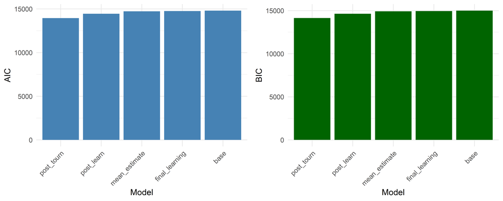

```r
# AIC comparison
p_aic <- ggplot(learning_fits$results, aes(x = reorder(model, AIC), y = AIC)) +
  geom_col(fill = "steelblue") +
  labs(x = "Model", y = "AIC") +
  theme_minimal(base_size = 12) +
  theme(axis.text.x = element_text(angle = 45, hjust = 1))

# BIC comparison
p_bic <- ggplot(learning_fits$results, aes(x = reorder(model, BIC), y = BIC)) +
  geom_col(fill = "darkgreen") +
  labs(x = "Model", y = "BIC") +
  theme_minimal(base_size = 12) +
  theme(axis.text.x = element_text(angle = 45, hjust = 1))

gridExtra::grid.arrange(p_aic, p_bic, ncol = 2)
```

### Best Learning Model Summary

```r
summary(learning_fits$best_model)
```

```
## Generalized linear mixed model fit by maximum likelihood (Laplace
##   Approximation) [glmerMod]
##  Family: binomial  ( logit )
## Formula: accepted ~ Age_resc + Gender + postTournRat + normOutMag + effPrp +
##     valence + (1 + postTournRat + normOutMag + effPrp + valence |
##     prolificID)
##    Data: data
## Control: glmerControl(optimizer = "bobyqa", optCtrl = list(maxfun = 2e+05))
##
##       AIC       BIC    logLik -2*log(L)  df.resid
##   13950.7   14145.0   -6951.4   13902.7     24168
##
## Scaled residuals:
##      Min       1Q   Median       3Q      Max
## -17.9614   0.0092   0.0859   0.2634   9.8444
##
## Random effects:
##  Groups     Name         Variance Std.Dev. Corr
##  prolificID (Intercept)  38.162   6.178
##             postTournRat 22.093   4.700    -0.20
##             normOutMag    2.754   1.659     0.02 -0.13
##             effPrp       71.444   8.452    -0.85 -0.16 -0.10
##             valence1      1.207   1.098    -0.13 -0.11 -0.23  0.04
## Number of obs: 24192, groups:  prolificID, 252
##
## Fixed effects:
##                                                    Estimate Std. Error z value
## (Intercept)                                         8.79837    0.48348  18.198
## Age_resc                                           -0.01720    0.14873  -0.116
## GenderNon-binary (would like to give more detail)  -1.08160    2.24308  -0.482
## GenderRather not say                                3.60796    2.59788   1.389
## GenderWoman (including Trans Female/Trans Woman)    0.22546    0.29967   0.752
## postTournRat                                        6.01426    0.34584  17.390
## normOutMag                                          0.33781    0.14479   2.333
## effPrp                                            -12.77610    0.61589 -20.744
## valence1                                            0.39081    0.09044   4.321
##                                                   Pr(>|z|)
## (Intercept)                                        < 2e-16 ***
## Age_resc                                            0.9079
## GenderNon-binary (would like to give more detail)   0.6297
## GenderRather not say                                0.1649
## GenderWoman (including Trans Female/Trans Woman)    0.4518
## postTournRat                                       < 2e-16 ***
## normOutMag                                          0.0196 *
## effPrp                                             < 2e-16 ***
## valence1                                          1.55e-05 ***
## ---
## Signif. codes:  0 '***' 0.001 '**' 0.01 '*' 0.05 '.' 0.1 ' ' 1
##
## Correlation of Fixed Effects:
##             (Intr) Ag_rsc G(ltgmd GndRns GW(TFW pstTrR nrmOtM effPrp
## Age_resc     0.008
## GnN-(ltgmd) -0.043 -0.008
## GndrRthrnts -0.038 -0.060  0.008
## GndW(TF/TW) -0.299 -0.025  0.067   0.059
## postTournRt -0.153 -0.009 -0.003   0.016 -0.006
## normOutMag  -0.018  0.001 -0.001   0.004  0.004 -0.145
## effPrp      -0.826  0.002  0.003  -0.005 -0.009 -0.171 -0.077
## valence1    -0.108  0.004  0.000   0.005  0.004 -0.087 -0.141  0.021
```

## Fit Mental Health Models

```r
mh_fits <- fit_model_set(tbtDf, mental_health_models, "mental health models")
```

```
## Fitting mental health models...
##   Fitting model 1/4: base
##   Fitting model 2/4: shaps
##   Fitting model 3/4: transdiagnostic
##   Fitting model 4/4: fatigue
##
## Best model by AIC: shaps
```

### Model Comparison - Mental Health Models

```r
DT::datatable(mh_fits$results,
          caption = "Mental Health Models Comparison",
          options = list(pageLength = 10))
```

|  | model | AIC | BIC |
| --- | --- | --- | --- |
| 1 | base | 13950.73786414338 | 14144.98851883889 |
| 2 | shaps | 13947.77380613053 | 14150.11823810501 |
| 3 | transdiagnostic | 13954.580635353 | 14173.11262188544 |
| 4 | fatigue | 13952.32836547273 | 14154.67279744721 |

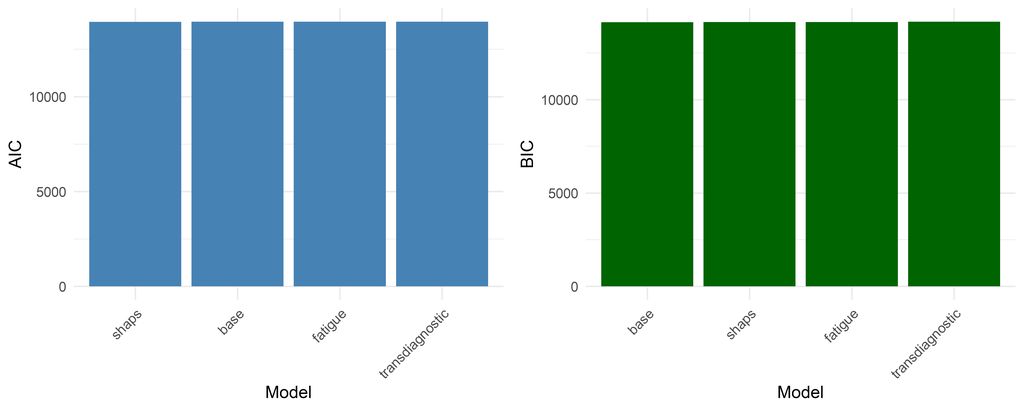

```r
# AIC comparison
p_aic_mh <- ggplot(mh_fits$results, aes(x = reorder(model, AIC), y = AIC)) +
  geom_col(fill = "steelblue") +
  labs(x = "Model", y = "AIC") +
  theme_minimal(base_size = 12) +
  theme(axis.text.x = element_text(angle = 45, hjust = 1))

# BIC comparison
p_bic_mh <- ggplot(mh_fits$results, aes(x = reorder(model, BIC), y = BIC)) +
  geom_col(fill = "darkgreen") +
  labs(x = "Model", y = "BIC") +
  theme_minimal(base_size = 12) +
  theme(axis.text.x = element_text(angle = 45, hjust = 1))

gridExtra::grid.arrange(p_aic_mh, p_bic_mh, ncol = 2)
```

### Best Mental Health Model Summary

```r
summary(mh_fits$best_model)
```

```
## Generalized linear mixed model fit by maximum likelihood (Laplace
##   Approximation) [glmerMod]
##  Family: binomial  ( logit )
## Formula: accepted ~ Age_resc + Gender + postTournRat + normOutMag + effPrp +
##     valence + SHAPS_resc + (1 + postTournRat + normOutMag + effPrp +
##     valence | prolificID)
##    Data: data
## Control: glmerControl(optimizer = "bobyqa", optCtrl = list(maxfun = 2e+05))
##
##       AIC       BIC    logLik -2*log(L)  df.resid
##   13947.8   14150.1   -6948.9   13897.8     24167
##
## Scaled residuals:
##      Min       1Q   Median       3Q      Max
## -18.0513   0.0092   0.0857   0.2619   9.7661
##
## Random effects:
##  Groups     Name         Variance Std.Dev. Corr
##  prolificID (Intercept)  38.313   6.190
##             postTournRat 22.116   4.703    -0.21
##             normOutMag    2.754   1.660     0.02 -0.12
##             effPrp       71.119   8.433    -0.85 -0.17 -0.10
##             valence1      1.209   1.100    -0.13 -0.11 -0.23  0.05
## Number of obs: 24192, groups:  prolificID, 252
##
## Fixed effects:
##                                                    Estimate Std. Error z value
## (Intercept)                                         8.85130    0.48480  18.258
## Age_resc                                           -0.08102    0.15036  -0.539
## GenderNon-binary (would like to give more detail)  -1.04471    2.22682  -0.469
## GenderRather not say                                3.61851    2.60034   1.392
## GenderWoman (including Trans Female/Trans Woman)    0.19151    0.29863   0.641
## postTournRat                                        5.97586    0.34579  17.282
## normOutMag                                          0.34286    0.14482   2.367
## effPrp                                            -12.80270    0.61537 -20.805
## valence1                                            0.39520    0.09054   4.365
## SHAPS_resc                                         -0.34150    0.15020  -2.274
##                                                   Pr(>|z|)
## (Intercept)                                        < 2e-16 ***
## Age_resc                                            0.5900
## GenderNon-binary (would like to give more detail)   0.6390
## GenderRather not say                                0.1641
## GenderWoman (including Trans Female/Trans Woman)    0.5213
## postTournRat                                       < 2e-16 ***
## normOutMag                                          0.0179 *
## effPrp                                             < 2e-16 ***
## valence1                                          1.27e-05 ***
## SHAPS_resc                                          0.0230 *
## ---
## Signif. codes:  0 '***' 0.001 '**' 0.01 '*' 0.05 '.' 0.1 ' ' 1
##
## Correlation of Fixed Effects:
##             (Intr) Ag_rsc G(ltgmd GndRns GW(TFW pstTrR nrmOtM effPrp valnc1
## Age_resc    -0.001
## GnN-(ltgmd) -0.042 -0.010
## GndrRthrnts -0.038 -0.056  0.008
## GndW(TF/TW) -0.299 -0.011  0.066   0.059
## postTournRt -0.158 -0.012 -0.003   0.016 -0.007
## normOutMag  -0.019 -0.001 -0.001   0.004  0.003 -0.144
## effPrp      -0.825  0.006  0.003  -0.005 -0.007 -0.176 -0.076
## valence1    -0.106  0.004  0.000   0.004  0.003 -0.089 -0.140  0.024
## SHAPS_resc  -0.045  0.181 -0.012   0.013  0.070 -0.020 -0.008  0.023 -0.004
```

# Visualizations - Model Effects

## Fixed Effects

Fixed effects show the average impact of each predictor across all participants.

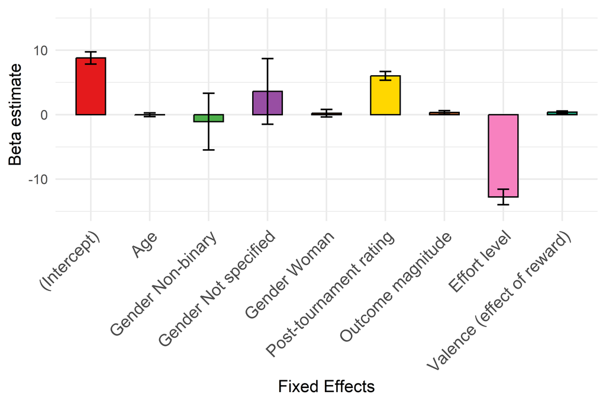

```r
# Extract fixed effects from best learning model
fixed_effects <- tidy(learning_fits$best_model, effects = "fixed", conf.int = TRUE, std.err = TRUE)

# Convert term to factor and explicitly set the order to match the original data
fixed_effects$term <- factor(fixed_effects$term, levels = fixed_effects$term)

# Create a vibrant color palette with unique colors for each bar
vibrant_colors <- c("#E41A1C", "#377EB8", "#4DAF4A", "#984EA3", "#FF7F00", "gold", "#A65628", "#F781BF", "#1B9E77")

# Create the bar plot with ordered factors and color updates
winMod_fixEffBar <- ggplot(fixed_effects, aes(x = term, y = estimate, fill = term)) +
  geom_bar(stat = "identity", color = "black", width = 0.5, linewidth = 0.7) +
  geom_errorbar(aes(ymin = conf.low, ymax = conf.high), width = 0.2, color = "black", linewidth = 0.8) +
  scale_fill_manual(values = vibrant_colors) +
  scale_x_discrete(labels = c("(Intercept)","Age","Gender Non-binary","Gender Not specified","Gender Woman","Post-tournament rating","Outcome magnitude","Effort level","Valence (effect of reward)")) +
  scale_y_continuous(seq(-15,15,by = 2)) +
  labs(
    x = "Fixed Effects",
    y = "Beta estimate") +
  lims(
    y = c(-15,15)
  ) +
  theme_minimal(base_size = 18) +
  theme(
    axis.text.x = element_text(size = 18, angle = 45, hjust = 1),
    legend.position = "none"
  )
print(winMod_fixEffBar)
```

## Random Effects

Random effects capture individual differences in how predictors affect choice behavior.

```r
# Extract random effects
random_effects <- ranef(learning_fits$best_model)$prolificID

# Assign random effects for each predictor
outProbEstRfx <- setNames(as.data.frame(random_effects$postTournRat), "outProbRfx")
effLvlRfx <- setNames(as.data.frame(random_effects$effPrp), "effRfx")
outMagRfx <- setNames(as.data.frame(random_effects$normOutMag), "outMagRfx")
valRfx <- setNames(as.data.frame(random_effects$valence1), "valRfx")
```

### Distribution of Random Slopes

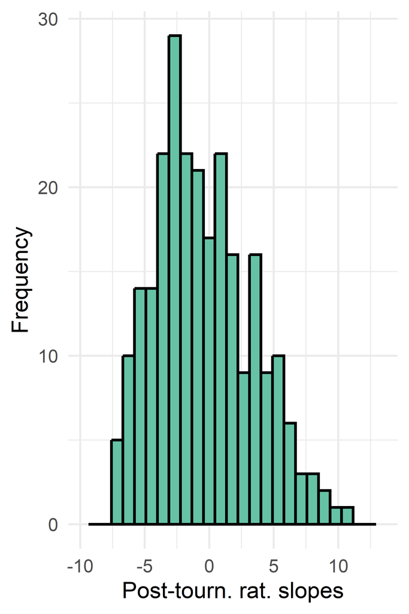

```r
# Post-tournament rating slopes
bin_count <- 20
x_min <- min(outProbEstRfx)
x_max <- max(outProbEstRfx)
bin_width <- (x_max - x_min) / bin_count

hist_postTourn <- ggplot(outProbEstRfx, aes(x = random_effects$postTournRat)) +
  geom_histogram(binwidth = bin_width, fill = "#66C2A5", color = "black", linewidth = 0.9) +
  scale_x_continuous(limits = c(x_min*1.3, x_max*1.3)) +
  labs(
    x = "Post-tourn. rat. slopes",
    y = "Frequency") +
  theme_minimal(base_size = 16)
print(hist_postTourn)
```

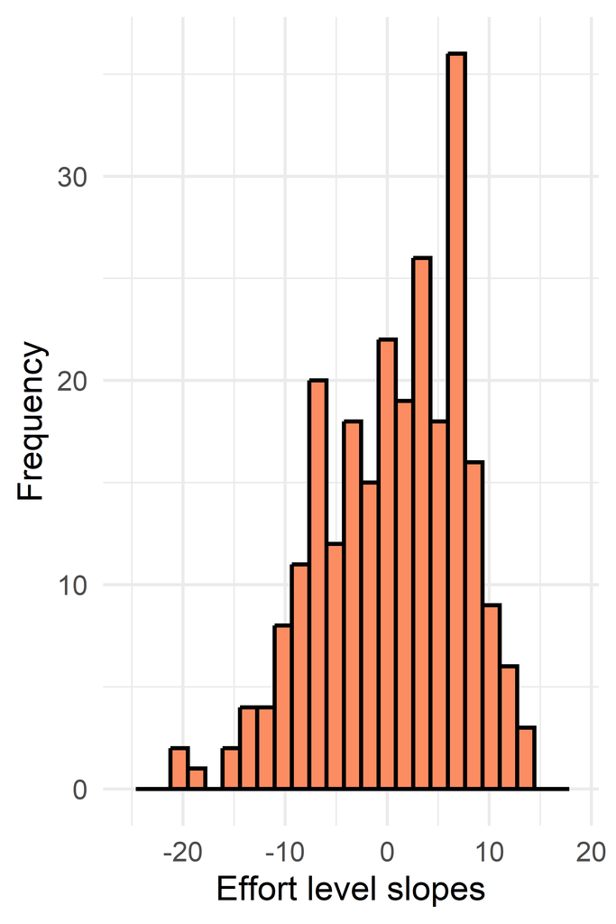

```r
# Effort level slopes
x_min <- min(effLvlRfx)
x_max <- max(effLvlRfx)
bin_width <- (x_max - x_min) / bin_count

hist_effort <- ggplot(effLvlRfx, aes(x = random_effects$effPrp)) +
  geom_histogram(binwidth = bin_width, fill = "#FC8D62", color = "black", linewidth = 0.9) +
  scale_x_continuous(limits = c(x_min*1.3, x_max*1.3)) +
  labs(
    x = "Effort level slopes",
    y = "Frequency") +
  theme_minimal(base_size = 16)
print(hist_effort)
```

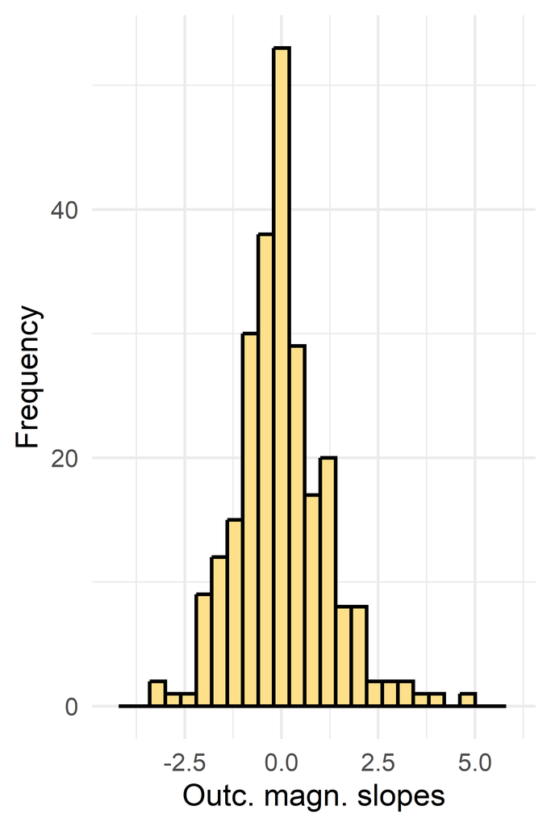

```r
# Outcome magnitude slopes
x_min <- min(outMagRfx)
x_max <- max(outMagRfx)
bin_width <- (x_max - x_min) / bin_count

hist_outMag <- ggplot(outMagRfx, aes(x = random_effects$normOutMag)) +
  geom_histogram(binwidth = bin_width, fill = "#FEE08B", color = "black", linewidth = 0.9) +
  scale_x_continuous(limits = c(x_min*1.3, x_max*1.3)) +
  labs(
    x = "Outc. magn. slopes",
    y = "Frequency") +
  theme_minimal(base_size = 16)
print(hist_outMag)
```

# Mental Health Effects

## SHAPS Main Effect

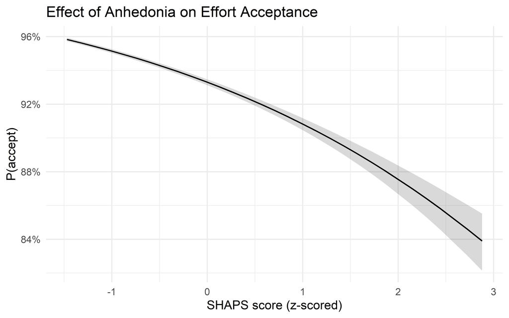

```r
# Check if SHAPS is in the model
if ("SHAPS_resc" %in% names(coef(mh_fits$best_model)$prolificID)) {

  ggpredict(mh_fits$best_model, terms = "SHAPS_resc [all]") %>%
    plot() +
    labs(x = "SHAPS score (z-scored)", y = "P(accept)",
         title = "Effect of Anhedonia on Effort Acceptance") +
    theme_minimal(base_size = 14)

} else {
  cat("SHAPS not included in best mental health model\n")
}
```

## Mental Health Model Visualizations

### Fixed Effects Bar Plot

Visualizes the fixed effect estimates from the best mental health model.

```r
# Extract fixed and random effects from the best mental health model
fixed_effects_mh <- fixef(mh_fits$best_model)
random_effects_mh <- ranef(mh_fits$best_model)$prolificID

# Create data frames for each random effect slope
# These capture individual differences in how predictors affect decisions
outProbEstRfx <- setNames(as.data.frame(random_effects_mh$postTournRat), "outProbRfx")
effLvlRfx <- setNames(as.data.frame(random_effects_mh$effPrp), "effRfx")
outMagRfx <- setNames(as.data.frame(random_effects_mh$normOutMag), "outMagRfx")
valRfx <- setNames(as.data.frame(random_effects_mh$valence1), "valRfx")
```

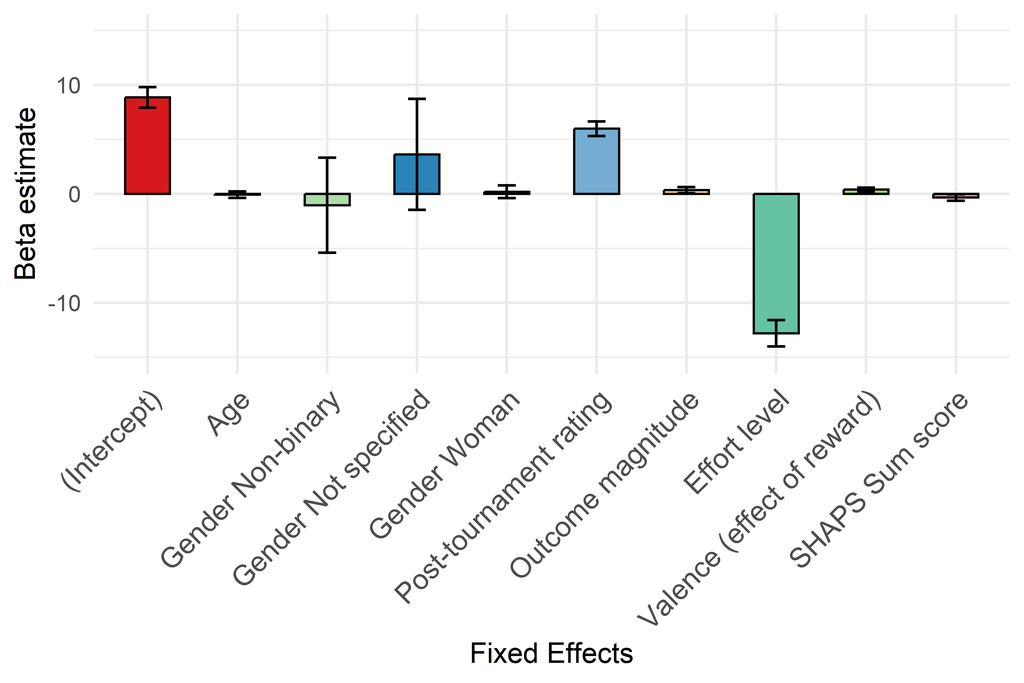

```r
# Extract fixed effects with confidence intervals for plotting
fixed_effects_mh_tidy <- tidy(mh_fits$best_model, effects = "fixed", conf.int = TRUE, std.err = TRUE)

# Convert term to factor to maintain order in plot
fixed_effects_mh_tidy$term <- factor(fixed_effects_mh_tidy$term, levels = fixed_effects_mh_tidy$term)

# Create vibrant color palette - one color per fixed effect
vibrant_colors <- c("#D7191C", "#FDAE61", "#ABDDA4", "#2B83BA", "#F46D43",
                    "#74ADD1", "#FEE08B", "#66C2A5", "#A6D854", "#E78AC3")

# Create bar plot showing fixed effect estimates with error bars
mhWinMod_fixEffBar <- ggplot(fixed_effects_mh_tidy, aes(x = term, y = estimate, fill = term)) +
  geom_bar(stat = "identity", color = "black", width = 0.5, linewidth = 0.7) +
  geom_errorbar(aes(ymin = conf.low, ymax = conf.high), width = 0.2, color = "black", linewidth = 0.8) +
  scale_fill_manual(values = vibrant_colors) +
  scale_x_discrete(labels = c("(Intercept)", "Age", "Gender Non-binary", "Gender Not specified", "Gender Woman",
                              "Post-tournament rating", "Outcome magnitude", "Effort level",
                              "Valence (effect of reward)", "SHAPS Sum score")) +
  scale_y_continuous(seq(-15, 15, by = 2)) +
  labs(
    x = "Fixed Effects",
    y = "Beta estimate") +
  lims(y = c(-15, 15)) +
  theme_minimal(base_size = 18) +
  theme(
    axis.text.x = element_text(size = 18, angle = 45, hjust = 1),
    legend.position = "none"
  )

print(mhWinMod_fixEffBar)
```

### Random Effect Slope Distributions

These histograms show the distribution of individual differences in how each predictor affects choice behavior.

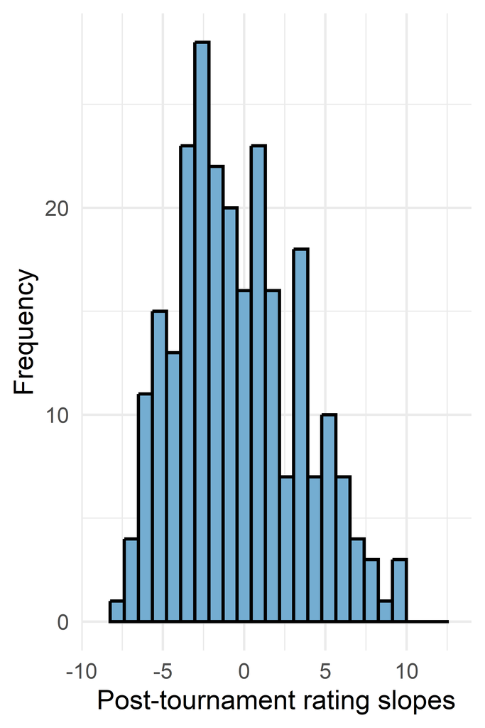

```r
# Post-tournament rating random slopes
# Shows individual variation in sensitivity to learned outcome probabilities
bin_count <- 20
x_min <- min(outProbEstRfx)
x_max <- max(outProbEstRfx)
bin_width <- (x_max - x_min) / bin_count

hist_ptr <- ggplot(outProbEstRfx, aes(x = outProbRfx)) +
  geom_histogram(binwidth = bin_width, fill = "#74ADD1", color = "black", linewidth = 0.9) +
  scale_x_continuous(limits = c(x_min*1.2, x_max*1.3)) +
  labs(
    x = "Post-tournament rating slopes",
    y = "Frequency") +
  theme_minimal(base_size = 16)

print(hist_ptr)
```

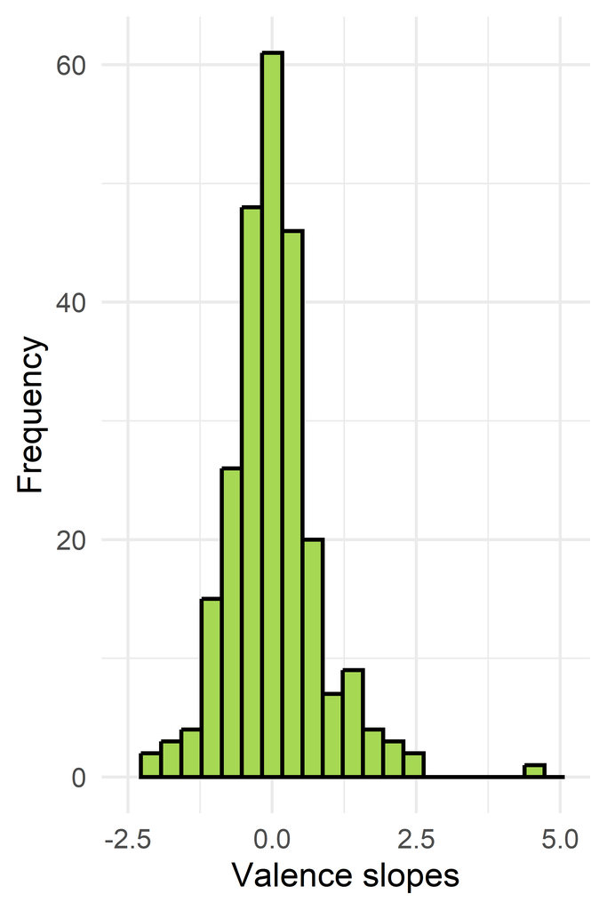

```r
# Valence random slopes
# Shows individual variation in reward vs. loss sensitivity
bin_count <- 20
x_min <- min(valRfx)
x_max <- max(valRfx)
bin_width <- (x_max - x_min) / bin_count

hist_val <- ggplot(valRfx, aes(x = random_effects_mh$valence1)) +
  geom_histogram(binwidth = bin_width, fill = "#A6D854", color = "black", linewidth = 0.9) +
  scale_x_continuous(limits = c(x_min*1.1, x_max*1.1)) +
  labs(
    x = "Valence slopes",
    y = "Frequency") +
  theme_minimal(base_size = 16)

print(hist_val)
```

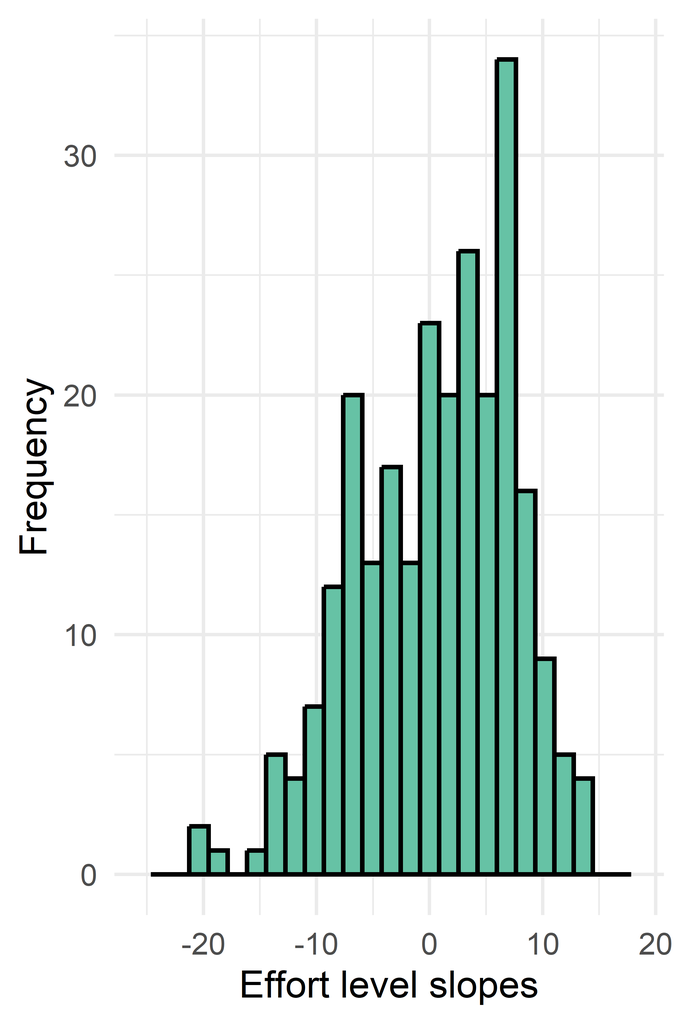

```r
# Effort level random slopes
# Shows individual variation in effort sensitivity
bin_count <- 20
x_min <- min(effLvlRfx)
x_max <- max(effLvlRfx)
bin_width <- (x_max - x_min) / bin_count

hist_effLvl <- ggplot(effLvlRfx, aes(x = random_effects_mh$effPrp)) +
  geom_histogram(binwidth = bin_width, fill = "#66C2A5", color = "black", linewidth = 0.9) +
  scale_x_continuous(limits = c(x_min*1.3, x_max*1.3)) +
  labs(
    x = "Effort level slopes",
    y = "Frequency") +
  theme_minimal(base_size = 16)

print(hist_effLvl)
```

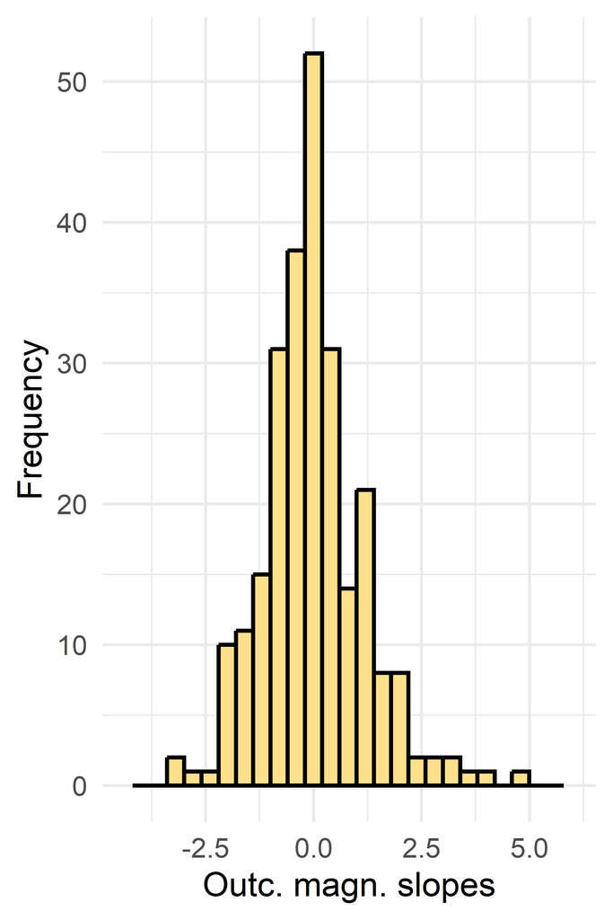

```r
# Outcome magnitude random slopes
# Shows individual variation in magnitude sensitivity
bin_count <- 20
x_min <- min(outMagRfx)
x_max <- max(outMagRfx)
bin_width <- (x_max - x_min) / bin_count

hist_outMag <- ggplot(outMagRfx, aes(x = random_effects_mh$normOutMag)) +
  geom_histogram(binwidth = bin_width, fill = "#FEE08B", color = "black", linewidth = 0.9) +
  scale_x_continuous(limits = c(x_min*1.3, x_max*1.3)) +
  labs(
    x = "Outc. magn. slopes",
    y = "Frequency") +
  theme_minimal(base_size = 16)

print(hist_outMag)
```

## SHAPS Interaction Models

Testing whether SHAPS (anhedonia) interacts with different decision variables. Each model tests a specific interaction while controlling for main effects.

```r
# Post-tournament rating × SHAPS interaction
# Tests whether anhedonia modulates sensitivity to learned outcome probabilities
intrMod_ptr_SHAPS <- glmer(accepted ~ Age_resc + Gender + normOutMag + effPrp + valence + postTournRat * SHAPS_resc
                           + (1 + postTournRat + normOutMag + valence + effPrp | prolificID),
                           data = tbtDf,
                           family = binomial(link = "logit"),
                           control = glmerControl(optimizer = 'bobyqa', optCtrl = list(maxfun = 2e5)))
summary(intrMod_ptr_SHAPS)
```

```
## Generalized linear mixed model fit by maximum likelihood (Laplace
##   Approximation) [glmerMod]
##  Family: binomial  ( logit )
## Formula: accepted ~ Age_resc + Gender + normOutMag + effPrp + valence +
##     postTournRat * SHAPS_resc + (1 + postTournRat + normOutMag +
##     valence + effPrp | prolificID)
##    Data: tbtDf
## Control: glmerControl(optimizer = "bobyqa", optCtrl = list(maxfun = 2e+05))
##
##       AIC       BIC    logLik -2*log(L)  df.resid
##   13945.2   14155.6   -6946.6   13893.2     24166
##
## Scaled residuals:
##      Min       1Q   Median       3Q      Max
## -18.0929   0.0087   0.0858   0.2639   9.5993
##
## Random effects:
##  Groups     Name         Variance Std.Dev. Corr
##  prolificID (Intercept)  37.987   6.163
##             postTournRat 21.426   4.629    -0.20
##             normOutMag    2.762   1.662     0.02 -0.13
##             valence1      1.210   1.100    -0.13 -0.11 -0.23
##             effPrp       71.128   8.434    -0.85 -0.17 -0.09  0.05
## Number of obs: 24192, groups:  prolificID, 252
##
## Fixed effects:
##                                                    Estimate Std. Error z value
## (Intercept)                                         8.82053    0.48315  18.256
## Age_resc                                           -0.08613    0.15040  -0.573
## GenderNon-binary (would like to give more detail)  -1.04213    2.22705  -0.468
## GenderRather not say                                3.61107    2.59394   1.392
## GenderWoman (including Trans Female/Trans Woman)    0.18494    0.29867   0.619
## normOutMag                                          0.34470    0.14495   2.378
## effPrp                                            -12.78967    0.61515 -20.791
## valence1                                            0.39685    0.09056   4.382
## postTournRat                                        6.02397    0.34281  17.572
## SHAPS_resc                                          0.01132    0.21945   0.052
## postTournRat:SHAPS_resc                            -0.71046    0.32799  -2.166
##                                                   Pr(>|z|)
## (Intercept)                                        < 2e-16 ***
```

[output cut: 21 more lines]

```
## valence1    -0.108  0.004  0.000   0.004  0.004 -0.140  0.025
## postTournRt -0.149 -0.014 -0.003   0.016 -0.009 -0.145 -0.179 -0.087
## SHAPS_resc  -0.041  0.114 -0.009   0.013  0.038 -0.006  0.015  0.002  0.036
## psTR:SHAPS_  0.014  0.014  0.002  -0.005  0.013  0.001  0.001 -0.007 -0.072
##             SHAPS_
## Age_resc
## GnN-(ltgmd)
## GndrRthrnts
## GndW(TF/TW)
## normOutMag
## effPrp
## valence1
## postTournRt
## SHAPS_resc
## psTR:SHAPS_ -0.729
```

```r
# Valence × SHAPS interaction
# Tests whether anhedonia differentially affects reward vs. loss processing
intrMod_val_SHAPS <- glmer(accepted ~ Age_resc + Gender + normOutMag + effPrp + postTournRat + valence * SHAPS_resc
                           + (1 + postTournRat + normOutMag + valence + effPrp | prolificID),
                           data = tbtDf,
                           family = binomial(link = "logit"),
                           control = glmerControl(optimizer = 'bobyqa', optCtrl = list(maxfun = 2e5)))
summary(intrMod_val_SHAPS)
```

```
## Generalized linear mixed model fit by maximum likelihood (Laplace
##   Approximation) [glmerMod]
##  Family: binomial  ( logit )
## Formula: accepted ~ Age_resc + Gender + normOutMag + effPrp + postTournRat +
##     valence * SHAPS_resc + (1 + postTournRat + normOutMag + valence +
##     effPrp | prolificID)
##    Data: tbtDf
## Control: glmerControl(optimizer = "bobyqa", optCtrl = list(maxfun = 2e+05))
##
##       AIC       BIC    logLik -2*log(L)  df.resid
##   13949.6   14160.1   -6948.8   13897.6     24166
##
## Scaled residuals:
##      Min       1Q   Median       3Q      Max
## -18.0426   0.0092   0.0857   0.2628   9.7909
##
## Random effects:
##  Groups     Name         Variance Std.Dev. Corr
##  prolificID (Intercept)  38.340   6.192
##             postTournRat 22.121   4.703    -0.21
##             normOutMag    2.755   1.660     0.02 -0.12
##             valence1      1.208   1.099    -0.13 -0.10 -0.23
##             effPrp       71.129   8.434    -0.84 -0.17 -0.10  0.04
## Number of obs: 24192, groups:  prolificID, 252
##
## Fixed effects:
##                                                    Estimate Std. Error z value
## (Intercept)                                         8.85552    0.48497  18.260
## Age_resc                                           -0.07989    0.15030  -0.532
## GenderNon-binary (would like to give more detail)  -1.03710    2.22584  -0.466
## GenderRather not say                                3.62261    2.60096   1.393
## GenderWoman (including Trans Female/Trans Woman)    0.19076    0.29851   0.639
## normOutMag                                          0.34138    0.14485   2.357
## effPrp                                            -12.80402    0.61542 -20.805
## postTournRat                                        5.97550    0.34581  17.280
## valence1                                            0.39110    0.09071   4.312
## SHAPS_resc                                         -0.36756    0.16370  -2.245
## valence1:SHAPS_resc                                 0.03642    0.08860   0.411
##                                                   Pr(>|z|)
## (Intercept)                                        < 2e-16 ***
```

[output cut: 21 more lines]

```
## postTournRt -0.159 -0.012 -0.003   0.016 -0.007 -0.144 -0.176
## valence1    -0.109  0.003  0.000   0.004  0.004 -0.139  0.023 -0.083
## SHAPS_resc  -0.047  0.165 -0.011   0.013  0.065 -0.001  0.022 -0.017  0.024
## vln1:SHAPS_  0.014  0.003  0.000  -0.003 -0.003 -0.015 -0.003 -0.003 -0.067
##             SHAPS_
## Age_resc
## GnN-(ltgmd)
## GndrRthrnts
## GndW(TF/TW)
## normOutMag
## effPrp
## postTournRt
## valence1
## SHAPS_resc
## vln1:SHAPS_ -0.399
```

```r
# Effort × SHAPS interaction
# Tests whether anhedonia modulates effort sensitivity
intrMod_eff_SHAPS <- glmer(accepted ~ Age_resc + Gender + normOutMag + postTournRat + effPrp * SHAPS_resc
                           + (1 + postTournRat + normOutMag + valence + effPrp | prolificID),
                           data = tbtDf,
                           family = binomial(link = "logit"),
                           control = glmerControl(optimizer = 'bobyqa', optCtrl = list(maxfun = 2e5)))
summary(intrMod_eff_SHAPS)
```

```
## Generalized linear mixed model fit by maximum likelihood (Laplace
##   Approximation) [glmerMod]
##  Family: binomial  ( logit )
## Formula: accepted ~ Age_resc + Gender + normOutMag + postTournRat + effPrp *
##     SHAPS_resc + (1 + postTournRat + normOutMag + valence + effPrp |
##     prolificID)
##    Data: tbtDf
## Control: glmerControl(optimizer = "bobyqa", optCtrl = list(maxfun = 2e+05))
##
##       AIC       BIC    logLik -2*log(L)  df.resid
##   13962.5   14164.8   -6956.2   13912.5     24167
##
## Scaled residuals:
##      Min       1Q   Median       3Q      Max
## -18.6237   0.0090   0.0864   0.2636   9.6320
##
## Random effects:
##  Groups     Name         Variance Std.Dev. Corr
##  prolificID (Intercept)  38.077   6.171
##             postTournRat 22.054   4.696    -0.20
##             normOutMag    2.782   1.668     0.02 -0.13
##             valence1      1.406   1.186    -0.14 -0.08 -0.23
##             effPrp       71.400   8.450    -0.84 -0.18 -0.09 -0.02
## Number of obs: 24192, groups:  prolificID, 252
##
## Fixed effects:
##                                                     Estimate Std. Error z value
## (Intercept)                                         9.063059   0.480168  18.875
## Age_resc                                           -0.064911   0.147628  -0.440
## GenderNon-binary (would like to give more detail)  -0.742307   2.186179  -0.340
## GenderRather not say                                3.721869   2.588801   1.438
## GenderWoman (including Trans Female/Trans Woman)    0.193365   0.293331   0.659
## normOutMag                                          0.421391   0.143928   2.928
## postTournRat                                        6.071187   0.344769  17.609
## effPrp                                            -12.754596   0.616902 -20.675
## SHAPS_resc                                          0.008927   0.448582   0.020
## effPrp:SHAPS_resc                                  -0.468513   0.598894  -0.782
##                                                   Pr(>|z|)
## (Intercept)                                        < 2e-16 ***
## Age_resc                                           0.66016
## GenderNon-binary (would like to give more detail)  0.73420
## GenderRather not say                               0.15052
## GenderWoman (including Trans Female/Trans Woman)   0.50977
## normOutMag                                         0.00341 **
## postTournRat                                       < 2e-16 ***
## effPrp                                             < 2e-16 ***
## SHAPS_resc                                         0.98412
## effPrp:SHAPS_resc                                  0.43404
## ---
## Signif. codes:  0 '***' 0.001 '**' 0.01 '*' 0.05 '.' 0.1 ' ' 1
##
## Correlation of Fixed Effects:
##             (Intr) Ag_rsc G(ltgmd GndRns GW(TFW nrmOtM pstTrR effPrp SHAPS_
## Age_resc    -0.001
## GnN-(ltgmd) -0.041 -0.010
## GndrRthrnts -0.037 -0.056  0.008
## GndW(TF/TW) -0.296 -0.010  0.066   0.058
## normOutMag  -0.036 -0.001 -0.001   0.006  0.004
## postTournRt -0.158 -0.013 -0.002   0.016 -0.008 -0.159
## effPrp      -0.830  0.006  0.002  -0.005 -0.007 -0.073 -0.187
## SHAPS_resc  -0.060  0.062 -0.004   0.004  0.022  0.000 -0.004  0.050
## effP:SHAPS_  0.048 -0.002  0.000   0.000  0.001 -0.004 -0.003 -0.046 -0.944
```

```r
# Outcome magnitude × SHAPS interaction
# Tests whether anhedonia modulates magnitude sensitivity
intrMod_mag_SHAPS <- glmer(accepted ~ Age_resc + Gender + effPrp + postTournRat + valence + normOutMag * SHAPS_resc
                           + (1 + postTournRat + normOutMag + valence + effPrp | prolificID),
                           data = tbtDf,
                           family = binomial(link = "logit"),
                           control = glmerControl(optimizer = 'bobyqa', optCtrl = list(maxfun = 2e5)))
summary(intrMod_mag_SHAPS)
```

```
## Generalized linear mixed model fit by maximum likelihood (Laplace
##   Approximation) [glmerMod]
##  Family: binomial  ( logit )
## Formula: accepted ~ Age_resc + Gender + effPrp + postTournRat + valence +
##     normOutMag * SHAPS_resc + (1 + postTournRat + normOutMag +
##     valence + effPrp | prolificID)
##    Data: tbtDf
## Control: glmerControl(optimizer = "bobyqa", optCtrl = list(maxfun = 2e+05))
##
##       AIC       BIC    logLik -2*log(L)  df.resid
##   13949.7   14160.2   -6948.9   13897.7     24166
##
## Scaled residuals:
##      Min       1Q   Median       3Q      Max
## -18.0515   0.0092   0.0856   0.2621   9.7537
##
## Random effects:
##  Groups     Name         Variance Std.Dev. Corr
##  prolificID (Intercept)  38.297   6.188
##             postTournRat 22.121   4.703    -0.21
##             normOutMag    2.757   1.661     0.02 -0.13
##             valence1      1.209   1.100    -0.13 -0.11 -0.23
##             effPrp       71.132   8.434    -0.85 -0.17 -0.09  0.05
## Number of obs: 24192, groups:  prolificID, 252
##
## Fixed effects:
##                                                    Estimate Std. Error z value
## (Intercept)                                         8.84899    0.48476  18.254
## Age_resc                                           -0.08131    0.15037  -0.541
## GenderNon-binary (would like to give more detail)  -1.04272    2.22704  -0.468
## GenderRather not say                                3.62077    2.59985   1.393
## GenderWoman (including Trans Female/Trans Woman)    0.19217    0.29866   0.643
## effPrp                                            -12.80212    0.61540 -20.803
## postTournRat                                        5.97566    0.34582  17.280
## valence1                                            0.39561    0.09055   4.369
## normOutMag                                          0.34620    0.14535   2.382
## SHAPS_resc                                         -0.32655    0.16678  -1.958
## normOutMag:SHAPS_resc                              -0.02875    0.13930  -0.206
##                                                   Pr(>|z|)
## (Intercept)                                        < 2e-16 ***
```

[output cut: 21 more lines]

```
## valence1    -0.106  0.004  0.000   0.004  0.004  0.024 -0.089
## normOutMag  -0.019 -0.001 -0.001   0.004  0.004 -0.075 -0.146 -0.138
## SHAPS_resc  -0.046  0.162 -0.011   0.013  0.065  0.021 -0.020  0.003  0.028
## nrOM:SHAPS_  0.012  0.001  0.000  -0.003 -0.005 -0.001  0.004 -0.014 -0.080
##             SHAPS_
## Age_resc
## GnN-(ltgmd)
## GndrRthrnts
## GndW(TF/TW)
## effPrp
## postTournRt
## valence1
## normOutMag
## SHAPS_resc
## nrOM:SHAPS_ -0.434
```

## SHAPS × Outcome Probability Interaction

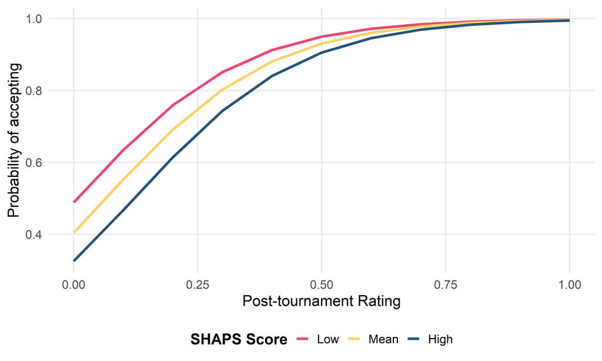

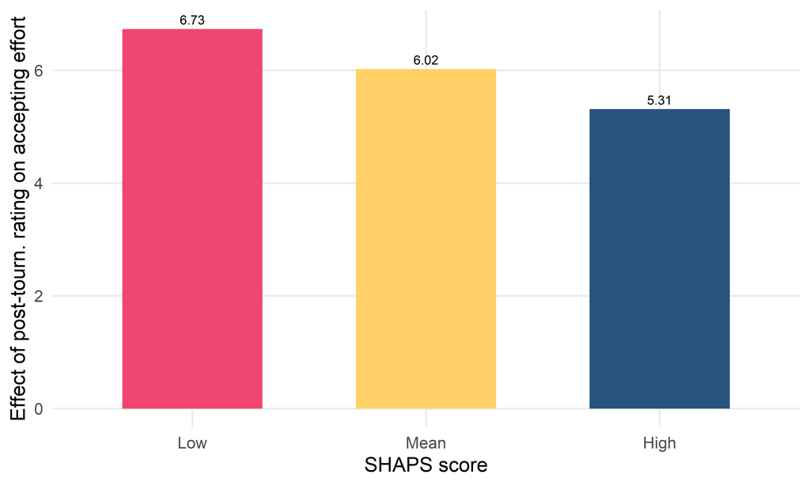

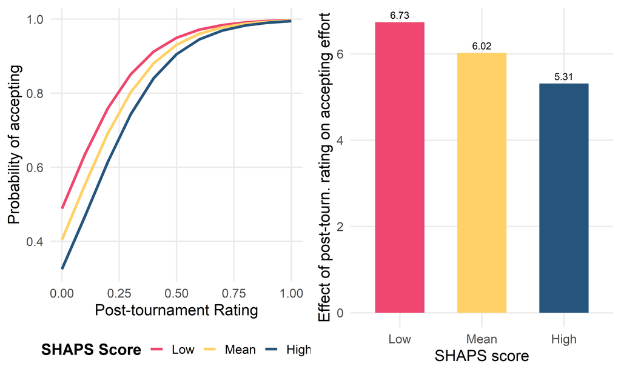

```r
if ("SHAPS_resc" %in% names(coef(mh_fits$best_model)$prolificID)) {

  # Create a grid of values for prediction
  # This generates combinations of predictor values to visualize the interaction
  newdata <- expand.grid(
    postTournRat = seq(0, 1, by = 0.1),          # Range of post-tournament ratings
    SHAPS_resc = c(-1, 0, 1),                # Low, mean, and high anhedonia
    Age_resc = 0,                                 # Set to mean (since rescaled)
    Gender = "Woman (including Trans Female/Trans Woman)",  # Most common category
    effPrp = mean(tbtDf$effPrp, na.rm = TRUE),   # Average effort level
    normOutMag = mean(tbtDf$normOutMag, na.rm = TRUE),  # Average outcome magnitude
    valence = levels(tbtDf$valence)[1]           # Use first level of valence
  )

  # Predict acceptance probabilities for each combination
  # re.form = NA means we use population-level (fixed) effects only
  newdata$predicted <- predict(mh_fits$best_model, newdata = newdata, type = "response", re.form = NA)

  # Convert SHAPS_resc to factor for better labeling in plots
  newdata$SHAPS_resc_factor <- factor(newdata$SHAPS_resc,
                                      levels = c(-1, 0, 1),
                                      labels = c("Low", "Mean", "High"))

  # Create line plot showing interaction
  # Shows how the effect of post-tournament rating varies by SHAPS level
  plot2 <- ggplot(newdata, aes(x = postTournRat, y = predicted, color = SHAPS_resc_factor)) +
    geom_line(linewidth = 1.5) +
    scale_color_manual(values = c("#ef476f", "#ffd166", "#26547c"),
                       name = "SHAPS Score") +
    labs(x = "Post-tournament Rating",
         y = "Probability of accepting") +
    theme_minimal(base_size = 18) +
    theme(legend.position = "bottom",
          panel.grid.minor = element_blank(),
          legend.title = element_text(face = "bold"))

  print(plot2)

  # Additional visualization: Showing the difference in slopes more explicitly
  # This bar plot makes it easier to see how anhedonia affects the slope
  #
  # Slope of postTournRat at a given SHAPS level is:
  #   slope = base_effect + interaction_coef * SHAPS_resc
  # base_effect is the main effect of postTournRat (from the model)
  # interaction_coef is the SHAPS_resc x postTournRat interaction (keep its sign!)
  # SHAPS_resc takes the same values used to build the line plot above (-1.5, 0, 1.5),
  # so the interaction coefficient must be multiplied by that value, not just
  # added/subtracted as a flat amount
  base_effect <- 6.02397
  interaction_coef <- -0.7105  # negative: higher SHAPS -> weaker (smaller) slope

  # Small helper so the slope formula is only written once and applied
  # consistently to each SHAPS_resc value below
  slope_at_shaps <- function(shaps_resc) {
    base_effect + interaction_coef * shaps_resc
  }

  slopes <- data.frame(
    # explicit factor levels (matching SHAPS_resc_factor above) so the bars
    # are ordered Low, Mean, High -- left to right -- exactly like plot2,
    # instead of ggplot's default alphabetical ordering (High, Low, Mean)
    SHAPS_level = factor(c("Low", "Mean", "High"), levels = c("Low", "Mean", "High")),
    Slope = c(slope_at_shaps(-1),  # Low SHAPS
              slope_at_shaps(0),     # Mean SHAPS
              slope_at_shaps(1))   # High SHAPS
  )

  # Create bar plot comparing slopes at different SHAPS levels
  plot3 <- ggplot(slopes, aes(x = SHAPS_level, y = Slope, fill = SHAPS_level)) +
    geom_col(width = 0.6) +
    # colors now line up with SHAPS_level's Low/Mean/High order, matching plot2's
    # scale_color_manual (Low = red, Mean = yellow, High = blue)
    scale_fill_manual(values = c("#ef476f", "#ffd166", "#26547c")) +
    labs(x = "SHAPS score",
         y = "Effect of post-tourn. rating on accepting effort") +
    theme_minimal(base_size = 18) +
    theme(legend.position = "none",
          panel.grid.minor = element_blank()) +
    geom_text(aes(label = round(Slope, 2)), vjust = -0.5, size = 4)

  print(plot3)

  # Combine both plots side by side for comprehensive visualization
  comb_intr_plot <- gridExtra::grid.arrange(plot2, plot3, ncol = 2)

  ggsave(
      filename = "shaps_interaction_combined.png",  # change path/name as needed
      plot = comb_intr_plot,
      dpi = 400,
      width = 12,
      height = 8,
      units = "in",
      bg = "white"   # avoids a transparent background when pasted into Word
  )

} else {
  cat("SHAPS not included in best mental health model\n")
}
```

# Descriptive Visualizations

## Learning Trajectories

Shows how participants learned stimulus values over trials.

```r
if (file.exists(file.path(data_dir, "allEstsByStim.csv"))) {

  # Read the raw estimates data.
  # header = FALSE is important here: this file has no column-name row,
  # it's pure numbers from the first line. Without header = FALSE, read.csv()
  # would wrongly treat that first data row as column headers and silently
  # drop it from the analysis.
  rawEstData <- read.csv(file.path(data_dir, "allEstsByStim.csv"), header = FALSE)

  # Convert raw matrix to tibble
  df <- as_tibble(rawEstData)

  # Rename columns for clarity
  colnames(df) <- c("stimulus", paste0("t", 1:(ncol(df)-1)))

  # Pivot to long format: one row per participant × trial
  long_df <- df %>%
    pivot_longer(
      cols = starts_with("t"),
      names_to = "trial",
      names_prefix = "t",
      names_transform = list(trial = as.integer),
      values_to = "estimate"
    )

  # Calculate mean and SE per stimulus × trial
  summary_df <- long_df %>%
    group_by(stimulus, trial) %>%
    dplyr::summarize(
      mean_est = mean(estimate, na.rm = TRUE),
      se_est = sd(estimate, na.rm = TRUE) / sqrt(n()),
      .groups = "drop"
    )

  # Plot learning trajectories
  p <- ggplot(summary_df, aes(x = trial, y = mean_est, color = factor(stimulus), group = factor(stimulus))) +
    geom_line(linewidth = 0.5) +
    geom_point(size = 1.2) +
    geom_ribbon(aes(ymin = mean_est - se_est, ymax = mean_est + se_est, fill = factor(stimulus)),
                alpha = 0.4, color = NA) +
    geom_hline(data = data.frame(
      stimulus = 1:8,
      h_line = ifelse(c(1:8) %in% c(1, 3, 5, 7), 0.25, 0.75)),
      aes(yintercept = h_line), linetype = "dashed", color = "black") +
    scale_x_continuous(breaks = seq(1, 16, by = 3)) +
    facet_wrap(~ stimulus, ncol = 2, labeller = labeller(stimulus = function(x) paste("Stimulus", x))) +
    ylim(0, 1) +
    labs(
      x = "Trial",
      y = "Average Rating",
      color = "Stimulus",
      fill = "Stimulus"
    ) +
    theme_minimal(base_size = 20) +
    theme(
      legend.position = "bottom",
      panel.background = element_rect(fill = "white", colour = "white"),
      panel.grid.minor = element_blank(),
      strip.background = element_rect(fill = "lightgray", color = NA),
      strip.text = element_text(face = "bold")
    )

  print(p)

} else {
  cat("Learning trajectory data (data/allEstsByStim.csv) not found\n")
}
```

[figure not shown]

## Post-Tournament Estimation Error

Shows the error in participants’ post-tournament outcome probability estimates. Each point represents one participant’s average estimation error. The yellow line at 0 indicates perfect accuracy.

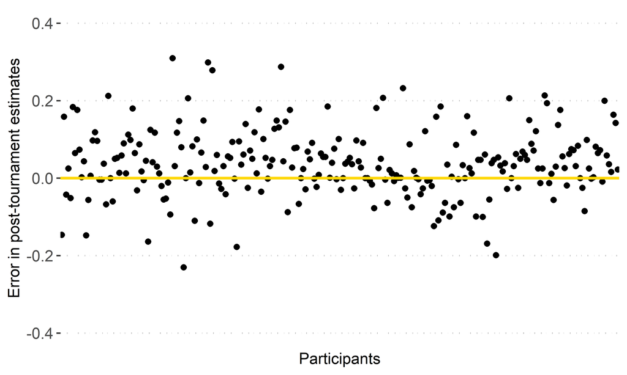

```r
# Create scatter plot of post-tournament estimation errors
# Each point represents one participant's average error across all stimuli
# Positive values = overestimation, negative values = underestimation
postTournErrScat <- ggplot(summDf, aes(x = prolificID, y = postTournErr)) +
  geom_point(color = "black") +
  geom_hline(yintercept = 0, color = "#fed700", linetype = "solid", linewidth = 1.5) +
  labs(
    x = "Participants",
    y = "Error in post-tournament estimates") +
  theme_pubclean(base_size = 18) +
  theme(legend.position = "none",
        axis.text.x = element_blank(),
        axis.text.y = element_text(size = 18),
        axis.ticks.x = element_blank(),
        axis.text.x.bottom = element_blank()) +
  ylim(-0.4, 0.4)

print(postTournErrScat)
```

## Final Learning Estimates

Shows how well participants learned each stimulus by the end of training.

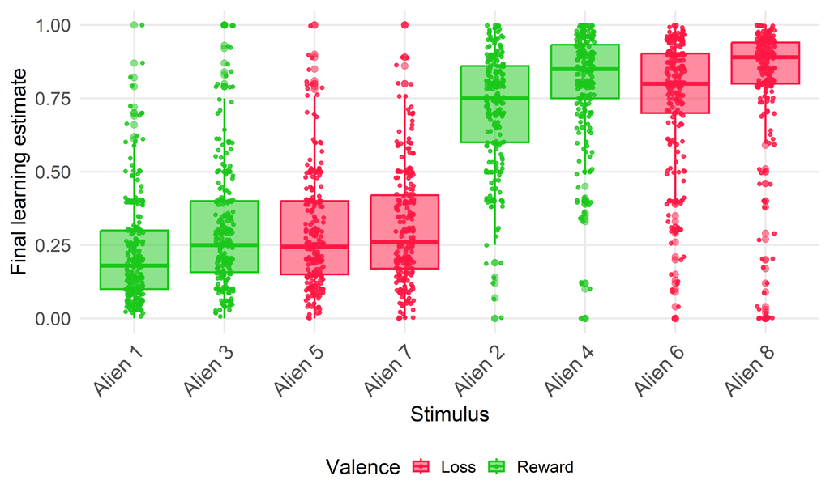

```r
# Reorder variables: odd numbers (1,3,5,7) then even numbers (2,4,6,8)
variables_to_mean <- c("finLearningEst_1", "finLearningEst_3", "finLearningEst_5", "finLearningEst_7",
                       "finLearningEst_2", "finLearningEst_4", "finLearningEst_6", "finLearningEst_8")

# Convert to long format with reordered variables
df_long <- summDf %>%
  tidyr::pivot_longer(cols = all_of(variables_to_mean),
                      names_to = "Variable",
                      values_to = "Value") %>%
  mutate(
    Variable = factor(Variable, levels = variables_to_mean),
    Valence = case_when(
      Variable %in% c("finLearningEst_1", "finLearningEst_2", "finLearningEst_3", "finLearningEst_4") ~ "Reward",
      Variable %in% c("finLearningEst_5", "finLearningEst_6", "finLearningEst_7", "finLearningEst_8") ~ "Loss"
    )
  )

# Custom x-axis labels
custom_labels <- c("Alien 1", "Alien 3", "Alien 5", "Alien 7",
                   "Alien 2", "Alien 4", "Alien 6", "Alien 8")

# Bright red and green colors
condition_colors <- c("Loss" = "#FF1744", "Reward" = "#1AC71A")

# Create publication-ready boxplot with scatter points
p <- ggplot(df_long, aes(x = Variable, y = Value, fill = Valence, color = Valence)) +
  geom_boxplot(alpha = 0.5) +
  geom_point(position = position_jitter(width = 0.1), alpha = 0.8, size = 1) +
  scale_fill_manual(values = condition_colors) +
  scale_color_manual(values = condition_colors) +
  scale_x_discrete(labels = custom_labels) +
  labs(x = "Stimulus", y = "Final learning estimate") +
  theme_minimal(base_size = 18) +
  ylim(0,1) +
  theme(
    axis.text.x = element_text(angle = 45, hjust = 1, size = 18),
    axis.text.y = element_text(size = 16),
    axis.title = element_text(size = 18),
    plot.title = element_text(size = 14, hjust = 0.5),
    panel.grid.minor = element_blank(),
    legend.position = "bottom"
  )
print(p)
```

## Questionnaire Distributions

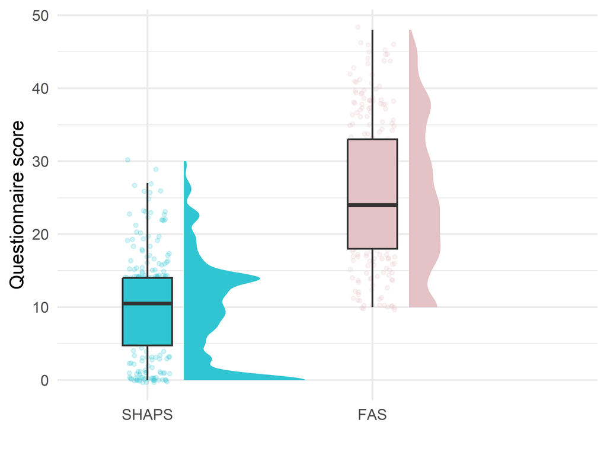

```r
# Prepare data for SHAPS and FAS
summ_long <- reshape2::melt(summDf, id.vars = "prolificID", measure.vars = c("SHAPS","FAS"))

# Create raincloud plot
shapsFasRain <- ggplot(summ_long, aes(x = variable, y = value, fill = as.factor(variable))) +
  ggdist::stat_halfeye(
    adjust = .5,
    width = .6,
    .width = 0,
    justification = -.3,
    point_colour = NA) +
  geom_point(
    inherit.aes = T,
    aes(color = as.factor(variable)),
    size = 1.5,
    alpha = .2,
    position = position_jitter(
      seed = 1, width = .1
    )
  ) +
  geom_boxplot(
    width = .22,
    outlier.shape = NA,
    aes(fill = as.factor(variable))) +
  coord_cartesian(xlim = c(1.2, 2.4), clip = "off") +
  scale_fill_brewer(palette = "Spectral") +
  xlim(0,50) +
  labs(
    x = "",
    y = "Questionnaire score") +
  theme_minimal(base_size = 18) +
  theme(panel.background = element_rect(fill = "white", colour = "white")) +
  theme(legend.position = "none") +
  scale_x_discrete(labels = c("SHAPS" = "SHAPS", "FAS" = "FAS")) +
  scale_fill_manual(values = c("SHAPS" = "#30c5d2","FAS" = "#E4C2C6")) +
  scale_color_manual(values = c("SHAPS" = "#30c5d2","FAS" = "#E4C2C6"))

print(shapsFasRain)
```

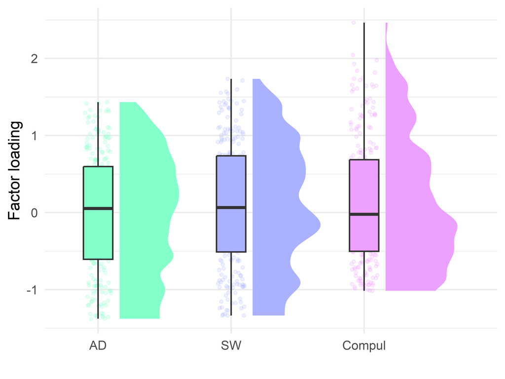

```r
# Prepare data for transdiagnostic factors
summ_long <- reshape2::melt(summDf, id.vars = "prolificID", measure.vars = c("AD","SW","Compul"))

# Create raincloud plot
transxRain <- ggplot(summ_long, aes(x = variable, y = value, fill = as.factor(variable))) +
  ggdist::stat_halfeye(
    adjust = .5,
    width = .6,
    .width = 0,
    justification = -.3,
    point_colour = NA) +
  geom_point(
    inherit.aes = T,
    aes(color = as.factor(variable)),
    size = 1.5,
    alpha = .2,
    position = position_jitter(
      seed = 1, width = .1
    )
  ) +
  geom_boxplot(
    width = .22,
    outlier.shape = NA,
    aes(fill = as.factor(variable))) +
  coord_cartesian(xlim = c(1.2, 3.4), clip = "off") +
  scale_fill_brewer(palette = "Spectral") +
  labs(
    x = "",
    y = "Factor loading") +
  theme_minimal(base_size = 18) +
  theme(panel.background = element_rect(fill = "white", colour = "white")) +
  theme(legend.position = "none") +
  scale_x_discrete(labels = c("AD" = "AD", "SW" = "SW", "Compul" = "Compul")) +
  scale_fill_manual(values = c("AD" = "#84ffc9","SW" = "#aab2ff", "Compul" = "#eca0ff")) +
  scale_color_manual(values = c("AD" = "#84ffc9","SW" = "#aab2ff", "Compul" = "#eca0ff"))

print(transxRain)
```

# Statistical Tests

## Partial Correlations

Examining relationships between anhedonia (SHAPS) and effort acceptance, controlling for age and gender.

```r
# Define control variables
control_vars <- cbind(as.numeric(summDf$Age), as.factor(summDf$Gender))

# Initialize results dataframe
pcor_results <- data.frame(
  comparison = character(),
  estimate = numeric(),
  p_value = numeric(),
  statistic = numeric(),
  stringsAsFactors = FALSE
)

# Low effort
if ("percAcceptByEffort_1" %in% names(summDf)) {
  pacc_low <- asin(sqrt(summDf$percAcceptByEffort_1 / 100))
  pcor_low <- pcor.test(summDf$SHAPS_resc, pacc_low, control_vars, method = "kendall")
  pcor_results <- rbind(pcor_results, data.frame(
    comparison = "SHAPS × Low effort acceptance",
    estimate = pcor_low$estimate,
    p_value = pcor_low$p.value,
    statistic = pcor_low$statistic
  ))
}

# Medium effort
if ("percAcceptByEffort_2" %in% names(summDf)) {
  pacc_med <- asin(sqrt(summDf$percAcceptByEffort_2 / 100))
  pcor_med <- pcor.test(summDf$SHAPS_resc, pacc_med, control_vars, method = "kendall")
  pcor_results <- rbind(pcor_results, data.frame(
    comparison = "SHAPS × Medium effort acceptance",
    estimate = pcor_med$estimate,
    p_value = pcor_med$p.value,
    statistic = pcor_med$statistic
  ))
}

# High effort
if ("percAcceptByEffort_3" %in% names(summDf)) {
  pacc_high <- asin(sqrt(summDf$percAcceptByEffort_3 / 100))
  pcor_high <- pcor.test(summDf$SHAPS_resc, pacc_high, control_vars, method = "kendall")
  pcor_results <- rbind(pcor_results, data.frame(
    comparison = "SHAPS × High effort acceptance",
    estimate = pcor_high$estimate,
    p_value = pcor_high$p.value,
    statistic = pcor_high$statistic
  ))
}

# Overall acceptance
if ("percAccept" %in% names(summDf)) {
  pcor_overall <- pcor.test(summDf$SHAPS_resc, summDf$percAccept, control_vars, method = "kendall")
  pcor_results <- rbind(pcor_results, data.frame(
    comparison = "SHAPS × Overall acceptance",
    estimate = pcor_overall$estimate,
    p_value = pcor_overall$p.value,
    statistic = pcor_overall$statistic
  ))
}

print(pcor_results)
```

```
##                         comparison    estimate    p_value  statistic
## 1    SHAPS × Low effort acceptance -0.03668291 0.38760940 -0.8639609
## 2 SHAPS × Medium effort acceptance -0.08608988 0.04260106 -2.0276003
## 3   SHAPS × High effort acceptance -0.08326919 0.04985953 -1.9611671
## 4       SHAPS × Overall acceptance -0.08080835 0.05701327 -1.9032091
```

## Supplementary Figure 6 - SHAPS Effects on Effort Acceptance

### SHAPS × Effort Level Interaction

Shows how anhedonia (SHAPS) moderates the effect of effort level on acceptance probability. Three lines represent low (-1.5 SD), mean (0), and high (3 SD) SHAPS scores.

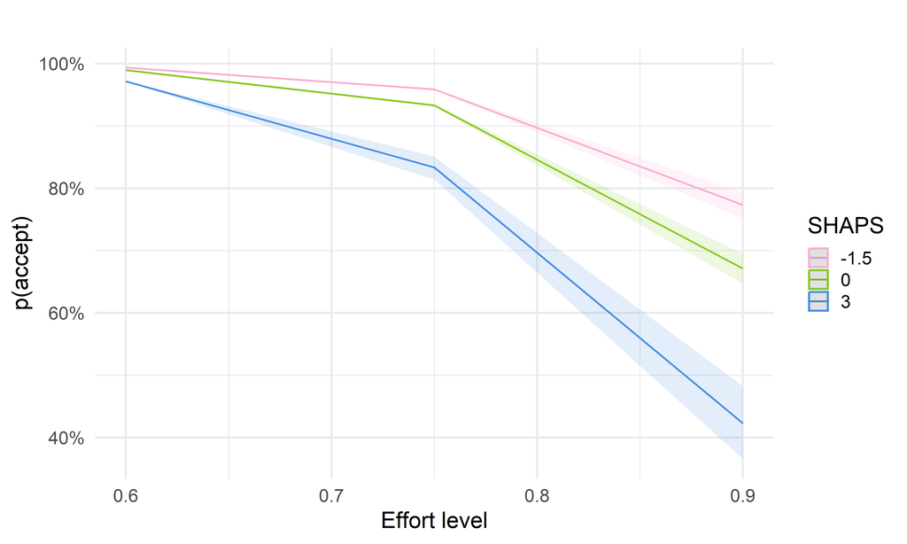

```r
# Generate marginal effects predictions for SHAPS × effort interaction
# Shows predicted probability of accepting effort at different SHAPS levels
# type = "fe" means fixed effects only (population-level predictions)

mhmod <- mh_fits$best_model
mhMod_SHAPS_ptr_plot <- ggpredict(mhmod,
                                  terms = c("effPrp [all]",           # Range of effort levels
                                           "SHAPS_resc [-1.5, 0, 3]"), # Low, mean, high SHAPS
                                  type = "fixed") %>%
  plot() +
  # Custom color scheme for SHAPS levels
  scale_fill_manual(values = c("#F9AED3",      # Low SHAPS (pink)
                               "#8AC926",      # Mean SHAPS (green)
                               "#4A90E0")) +   # High SHAPS (blue)
  scale_colour_manual(values = c("#F9AED3", "#8AC926", "#4A90E0")) +
  labs(
    title = "",
    x = "Effort level",
    y = "p(accept)",
    colour = "SHAPS"
  ) +
  theme_minimal(base_size = 18) +
  theme(legend.position = "right")

print(mhMod_SHAPS_ptr_plot)
```

### SHAPS Main Effect on Acceptance Probability

Shows the main effect of anhedonia on overall effort acceptance probability, controlling for all other variables in the model.

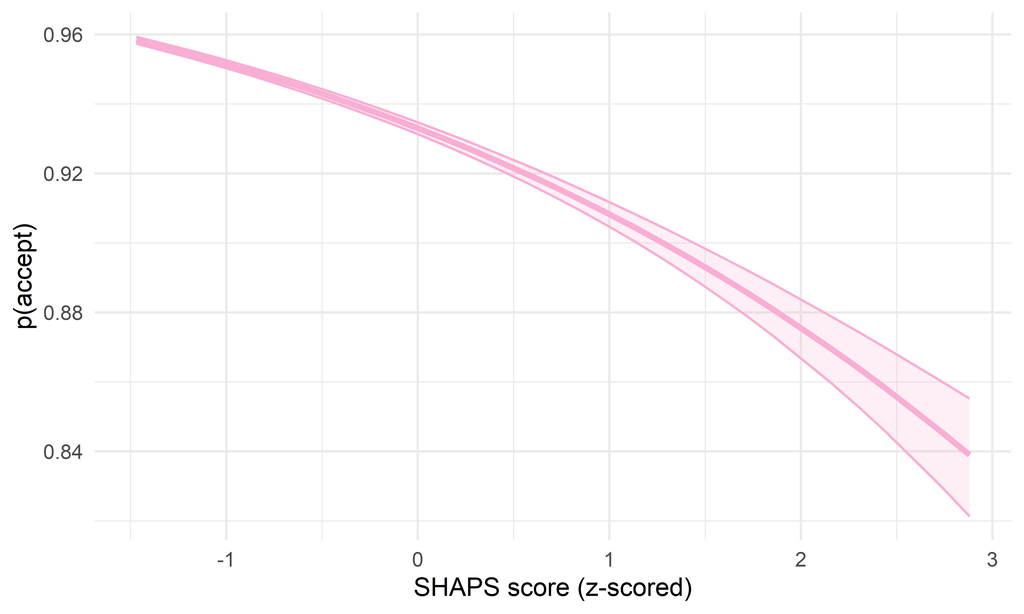

```r
# Generate marginal effects for SHAPS main effect
# Shows how acceptance probability changes across the full range of SHAPS scores
marginal_effects <- ggpredict(mh_fits$best_model, terms = "SHAPS_resc [all]")

# Create line plot with confidence ribbon
# Pink color emphasizes the anhedonia measure
mhWinMod_SHAPS_pAccept_plot <- ggplot(marginal_effects, aes(x = x, y = predicted)) +
  # Main effect line
  geom_line(color = "#F9AED3", linewidth = 2) +
  # 95% confidence interval ribbon
  geom_ribbon(aes(ymin = conf.low, ymax = conf.high),
              alpha = 0.2,           # Transparency for ribbon
              color = "#F9AED3",     # Ribbon border color
              fill = "#F9AED3") +    # Ribbon fill color
  labs(
    x = "SHAPS score (z-scored)",
    y = "p(accept)"
  ) +
  theme_minimal(base_size = 18)

print(mhWinMod_SHAPS_pAccept_plot)
```

# Summary

## Sample Characteristics

```r
summary_stats <- data.frame(
  Measure = c("Total participants", "Total trials", "Mean age (SD)",
              "Gender (% female)", "Mean SHAPS (SD)", "Mean FAS (SD)"),
  Value = c(
    length(unique(tbtDf$prolificID)),
    nrow(tbtDf),
    sprintf("%.2f (%.2f)", mean(summDf$Age, na.rm = TRUE), sd(summDf$Age, na.rm = TRUE)),
    sprintf("%.2f%%", mean(summDf$Gender == "Woman (including Trans Female/Trans Woman)", na.rm = TRUE) * 100),
    sprintf("%.2f (%.2f)", mean(summDf$SHAPS, na.rm = TRUE), sd(summDf$SHAPS, na.rm = TRUE)),
    sprintf("%.2f (%.2f)", mean(summDf$FAS, na.rm = TRUE), sd(summDf$FAS, na.rm = TRUE))
  )
)

print(summary_stats)
```

```
##              Measure         Value
## 1 Total participants           252
## 2       Total trials         24192
## 3      Mean age (SD) 38.93 (11.92)
## 4  Gender (% female)        49.60%
## 5    Mean SHAPS (SD)  10.17 (6.94)
## 6      Mean FAS (SD)  25.74 (9.60)
```